# Kristin Jacobs Coral Aquatic Preserve

SEACAR Water Quality Analysis

Last compiled on 15 July, 2026

# Indicators

## Nutrients

### Total Nitrogen - Discrete

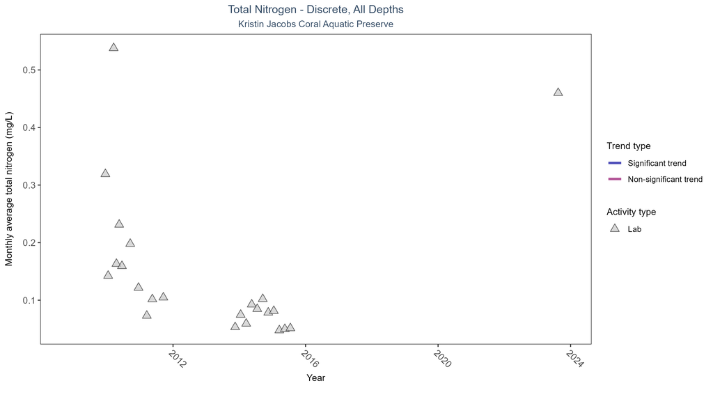

Scatter plot of monthly average total nitrogen over time. If the time series included ten or more years of discrete observations, a significant (blue) or non-significant (magenta) trend line is also shown. Only nitrogen values obtained from laboratory analyses (triangles) are included in the plot.

Table:

There was insufficient data to fit a model for total nitrogen.

| Activity Type | Statistical Trend | Sample Count | Years with Data | Period of Record | Median Result Value | Tau | Sen Intercept | Sen Slope | P |
| --- | --- | --- | --- | --- | --- | --- | --- | --- | --- |
| Lab | Insufficient data | 871 | 7 | 2009 - 2023 | 0.07 | - | - | - | - |

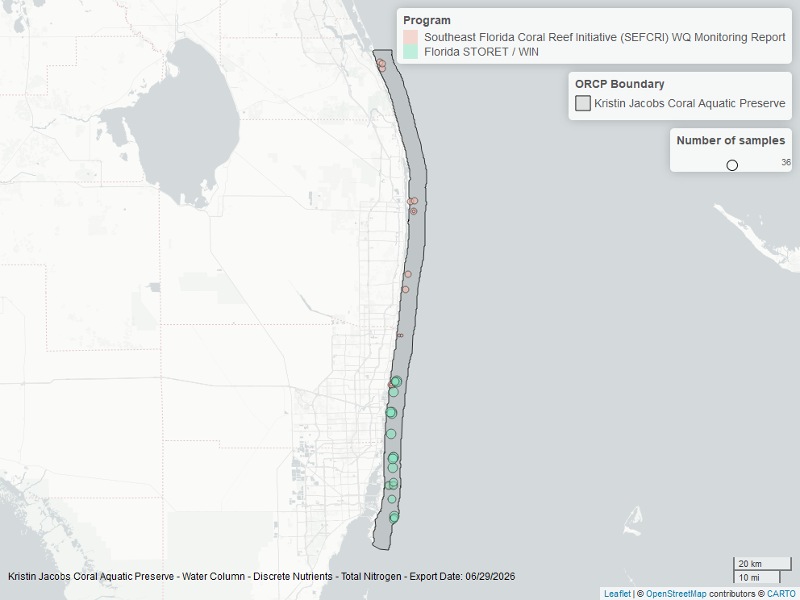

Map showing location of discrete water quality sampling locations within the boundaries of *Kristin Jacobs Coral Aquatic Preserve*. The bubble size on the maps above reflect the amount of data available at each sampling site.

### Total Phosphorus - Discrete

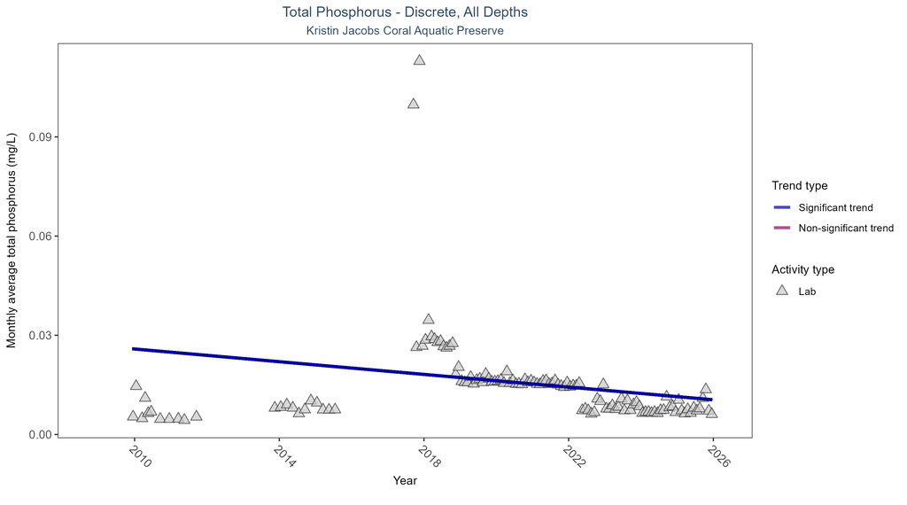

Scatter plot of monthly average total phosphorus over time. If the time series included ten or more years of discrete observations, a significant (blue) or non-significant (magenta) trend line is also shown. Only phosphorus values obtained from laboratory analyses (triangles) are included in the plot.

Table:

Monthly average total phosphorus decreased by less than 0.01 mg/L per year.

| Activity Type | Statistical Trend | Sample Count | Years with Data | Period of Record | Median Result Value | Tau | Sen Intercept | Sen Slope | P |
| --- | --- | --- | --- | --- | --- | --- | --- | --- | --- |
| Lab | Decreasing trend | 19086 | 15 | 2009 - 2025 | 0.014 | -0.3523 | 0.02681 | -0.00096 | 0 |

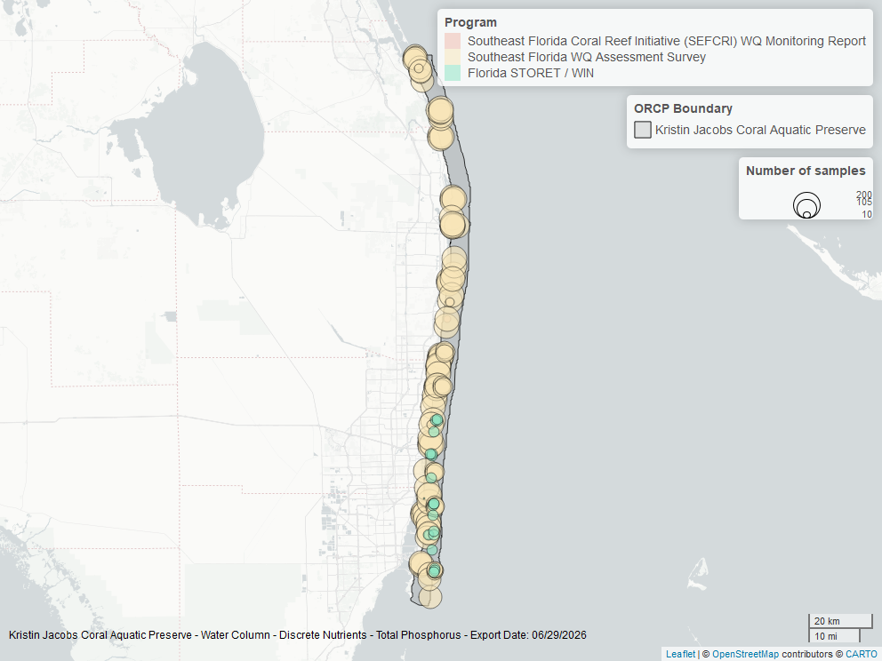

Map showing location of discrete water quality sampling locations within the boundaries of *Kristin Jacobs Coral Aquatic Preserve*. The bubble size on the maps above reflect the amount of data available at each sampling site.

## Water Quality

### Dissolved Oxygen - Discrete

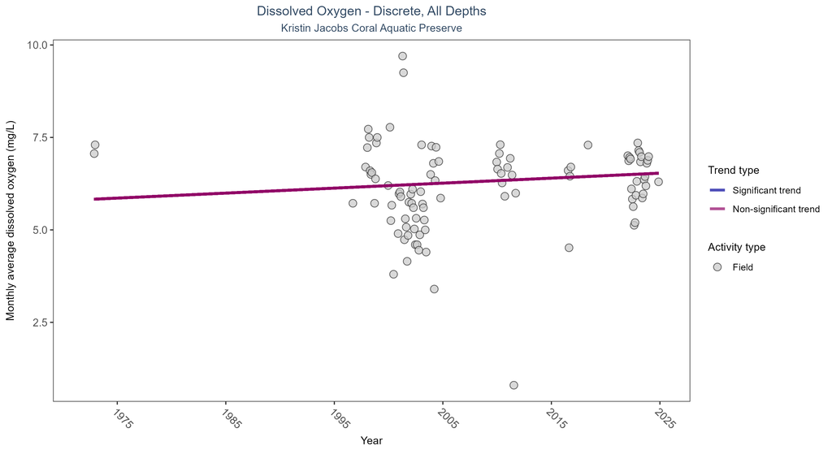

Scatter plot of monthly average dissolved oxygen over time. If the time series included ten or more years of discrete observations, a significant (blue) or non-significant (magenta) trend line is also shown. Only dissolved oxygen values measured in the field (circles) are included in the plot.

Table:

Dissolved oxygen showed no detectable trend between 1972 and 2024.

| Activity Type | Statistical Trend | Sample Count | Years with Data | Period of Record | Median Result Value | Tau | Sen Intercept | Sen Slope | P |
| --- | --- | --- | --- | --- | --- | --- | --- | --- | --- |
| Field | No detectable trend | 715 | 18 | 1972 - 2024 | 6.5 | 0.10593 | 5.81879 | 0.01349 | 0.3679 |

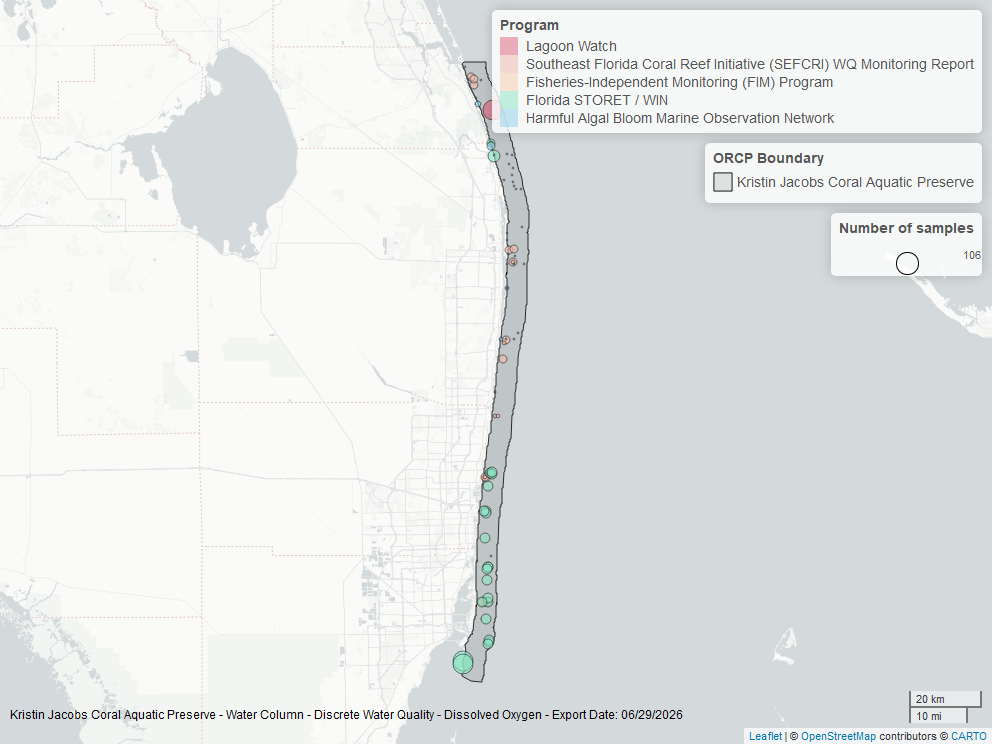

Map showing location of discrete water quality sampling locations within the boundaries of *Kristin Jacobs Coral Aquatic Preserve*. The bubble size on the maps above reflect the amount of data available at each sampling site.

### Dissolved Oxygen Saturation - Discrete

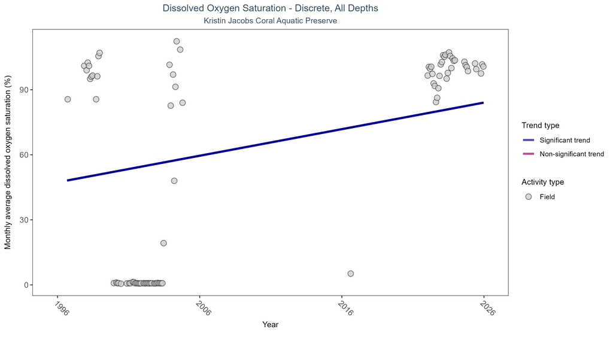

Scatter plot of monthly average dissolved oxygen saturation over time. If the time series included ten or more years of discrete observations, a significant (blue) or non-significant (magenta) trend line is also shown. Only dissolved oxygen saturation values measured in the field (circles) are included in the plot.

Table:

Monthly average dissolved oxygen saturation increased by 1.22% per year.

| Activity Type | Statistical Trend | Sample Count | Years with Data | Period of Record | Median Result Value | Tau | Sen Intercept | Sen Slope | P |
| --- | --- | --- | --- | --- | --- | --- | --- | --- | --- |
| Field | Increasing trend | 2030 | 14 | 1996 - 2025 | 101.2 | 0.37646 | 47.31868 | 1.22499 | 0.0001 |

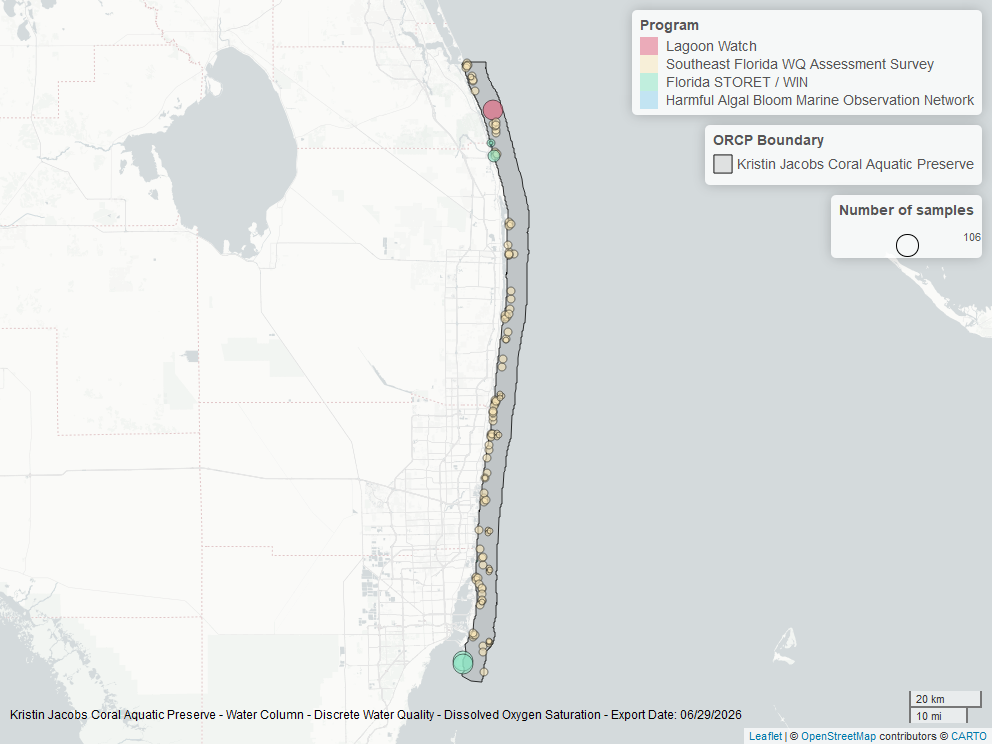

Map showing location of discrete water quality sampling locations within the boundaries of *Kristin Jacobs Coral Aquatic Preserve*. The bubble size on the maps above reflect the amount of data available at each sampling site.

### Salinity - Discrete

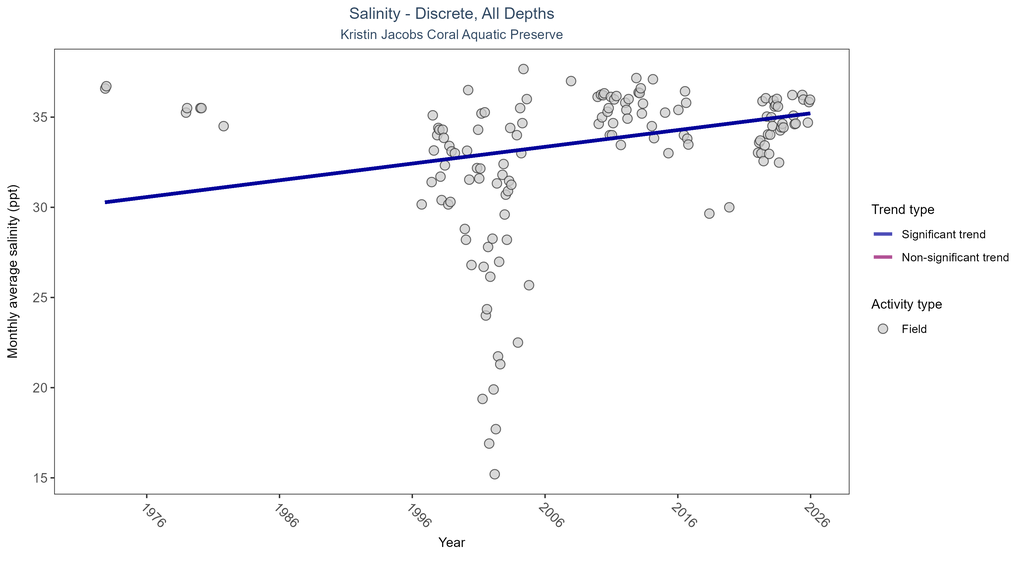

Scatter plot of monthly average salinity over time. If the time series included ten or more years of discrete observations, significant (blue) or non-significant (magenta) trend lines are also shown. Discrete salinity values derived from grab samples analyzed in the field (circles) or the laboratory (triangles) are both included in the plot.

Table:

Monthly average salinity increased by 0.09 ppt per year.

| Activity Type | Statistical Trend | Sample Count | Years with Data | Period of Record | Median Result Value | Tau | Sen Intercept | Sen Slope | P |
| --- | --- | --- | --- | --- | --- | --- | --- | --- | --- |
| All | Increasing trend | 2507 | 29 | 1972 - 2025 | 35.98 | 0.28075 | 30.19797 | 0.09282 | 0.0001 |

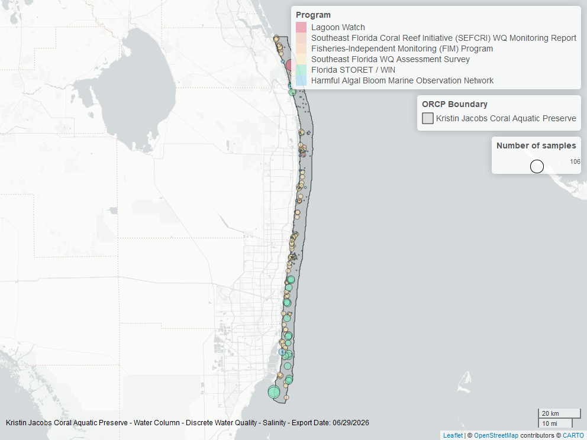

Map showing location of discrete water quality sampling locations within the boundaries of *Kristin Jacobs Coral Aquatic Preserve*. The bubble size on the maps above reflect the amount of data available at each sampling site.

### Water Temperature - Continuous

**National Data Buoy Center** - *5*

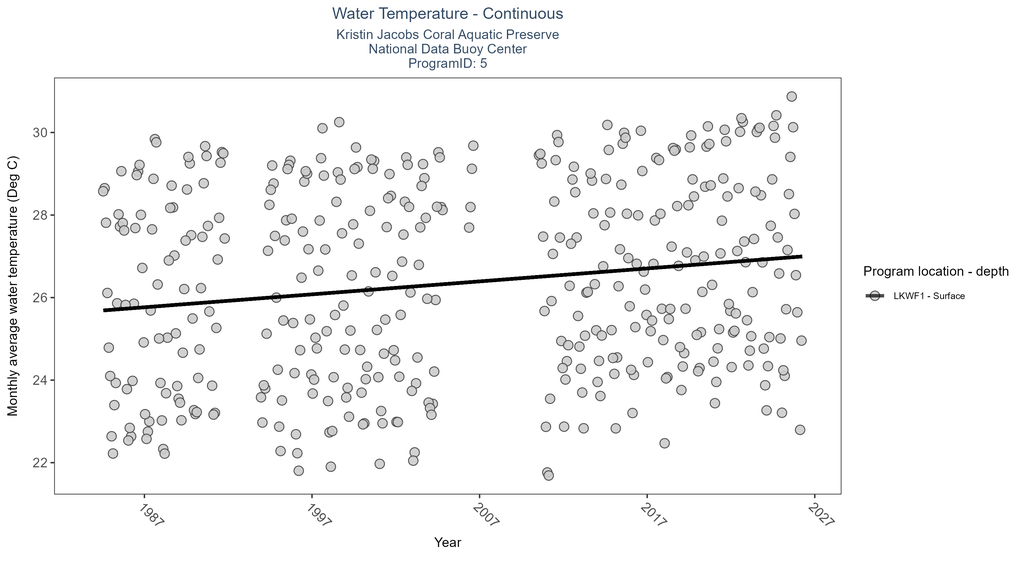

Scatter plot of monthly average water temperature over time at continuously monitored program locations. Each location is analyzed separately, with significant (blue) or non-significant (magenta) trend lines shown for time series that included five or more years of observations.

Table:

| Program Location | Statistical Trend | Sample Count | Years with Data | Period of Record | Median Result Value | Tau | Sen Intercept | Sen Slope | P |
| --- | --- | --- | --- | --- | --- | --- | --- | --- | --- |
| LKWF1 | Increasing trend | 1391062 | 38 | 1984 - 2026 | 26.5 | 0.42 | 25.67 | 0.03 | 0 |

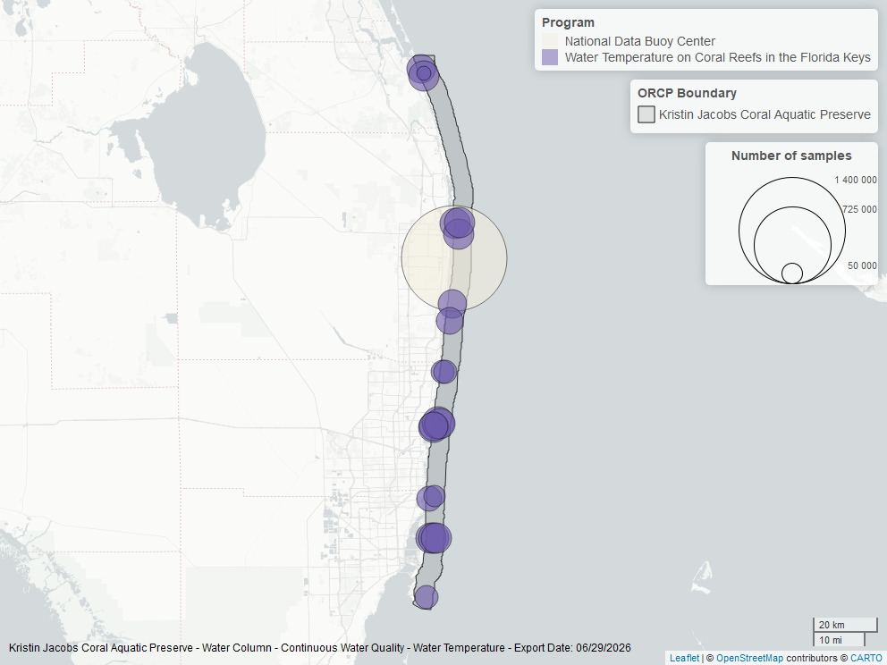

Map showing location of water temperature continuous water quality sampling locations within the boundaries of *Kristin Jacobs Coral Aquatic Preserve*. The bubble size on the maps above reflect the amount of data available at each sampling site.

**Water Temperature on Coral Reefs in the Florida Keys** - *986*

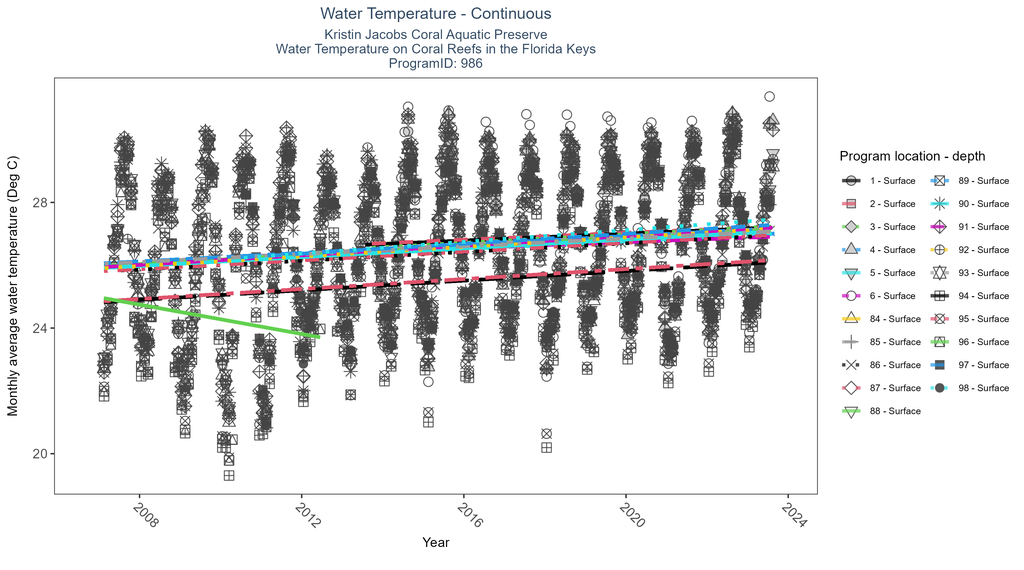

Scatter plot of monthly average water temperature over time at continuously monitored program locations. Each location is analyzed separately, with significant (blue) or non-significant (magenta) trend lines shown for time series that included five or more years of observations.

Table:

| Program Location | Statistical Trend | Sample Count | Years with Data | Period of Record | Median Result Value | Tau | Sen Intercept | Sen Slope | P |
| --- | --- | --- | --- | --- | --- | --- | --- | --- | --- |
| 1 | Increasing trend | 73700 | 11 | 2013 - 2023 | 26.50 | 0.23 | 26.62 | 0.06 | 0.00 |
| 2 | Increasing trend | 68589 | 11 | 2013 - 2023 | 26.74 | 0.32 | 26.65 | 0.06 | 0.00 |
| 3 | Increasing trend | 69054 | 11 | 2013 - 2023 | 26.69 | 0.32 | 26.51 | 0.07 | 0.00 |
| 4 | Increasing trend | 77960 | 11 | 2013 - 2023 | 26.69 | 0.28 | 26.36 | 0.06 | 0.00 |
| 5 | Increasing trend | 60729 | 11 | 2013 - 2023 | 26.69 | 0.28 | 26.33 | 0.06 | 0.00 |
| 6 | Increasing trend | 69753 | 11 | 2013 - 2023 | 26.84 | 0.19 | 26.41 | 0.05 | 0.01 |
| 84 | Increasing trend | 117729 | 17 | 2007 - 2023 | 26.37 | 0.40 | 25.91 | 0.07 | 0.00 |
| 85 | Increasing trend | 118414 | 17 | 2007 - 2023 | 26.29 | 0.38 | 26.03 | 0.07 | 0.00 |
| 86 | Increasing trend | 113127 | 17 | 2007 - 2023 | 26.20 | 0.39 | 25.80 | 0.07 | 0.00 |
| 87 | Increasing trend | 117324 | 17 | 2007 - 2023 | 26.50 | 0.37 | 25.81 | 0.07 | 0.00 |
| 88 | Increasing trend | 123687 | 17 | 2007 - 2023 | 26.42 | 0.38 | 25.97 | 0.07 | 0.00 |
| 89 | Increasing trend | 120476 | 17 | 2007 - 2023 | 26.32 | 0.38 | 26.06 | 0.07 | 0.00 |
| 90 | Increasing trend | 103477 | 17 | 2007 - 2023 | 26.48 | 0.39 | 25.91 | 0.07 | 0.00 |
| 91 | Increasing trend | 111048 | 17 | 2007 - 2023 | 26.60 | 0.38 | 25.93 | 0.08 | 0.00 |
| 92 | Increasing trend | 120189 | 17 | 2007 - 2023 | 26.50 | 0.40 | 25.90 | 0.08 | 0.00 |
| 93 | Increasing trend | 115688 | 17 | 2007 - 2023 | 26.56 | 0.38 | 26.04 | 0.06 | 0.00 |
| 94 | Increasing trend | 98419 | 17 | 2007 - 2023 | 25.62 | 0.34 | 24.82 | 0.08 | 0.00 |
| 95 | Increasing trend | 109401 | 17 | 2007 - 2023 | 25.62 | 0.36 | 24.85 | 0.08 | 0.00 |
| 96 | No detectable trend | 25550 | 6 | 2007 - 2012 | 24.87 | -0.25 | 24.98 | -0.23 | 0.08 |
| 97 | Increasing trend | 105832 | 14 | 2010 - 2023 | 26.50 | 0.42 | 26.21 | 0.08 | 0.00 |
| 98 | Increasing trend | 94894 | 14 | 2010 - 2023 | 26.45 | 0.42 | 26.18 | 0.09 | 0.00 |

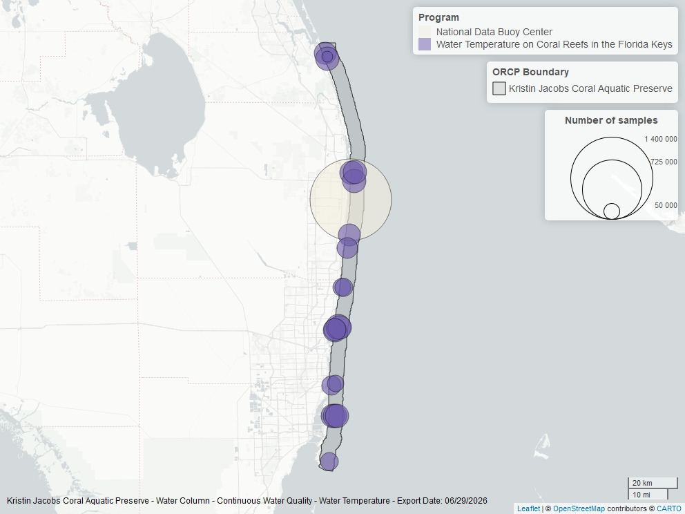

Map showing location of water temperature continuous water quality sampling locations within the boundaries of *Kristin Jacobs Coral Aquatic Preserve*. The bubble size on the maps above reflect the amount of data available at each sampling site.

### Water Temperature - Discrete

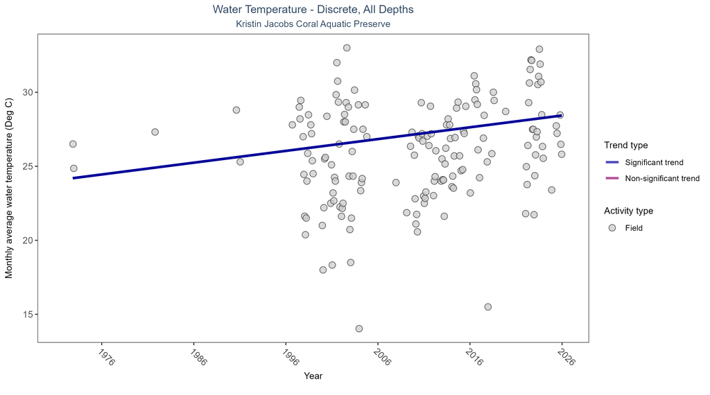

Scatter plot of monthly average water temperature over time. If the time series included ten or more years of discrete observations, a significant (blue) or non-significant (magenta) trend line is also shown. Only water temperature measurements taken in the field (circles) are included in the plot.

Table:

Monthly average water temperature increased by 0.08°C per year.

| Activity Type | Statistical Trend | Sample Count | Years with Data | Period of Record | Median Result Value | Tau | Sen Intercept | Sen Slope | P |
| --- | --- | --- | --- | --- | --- | --- | --- | --- | --- |
| Field | Increasing trend | 2540 | 29 | 1972 - 2025 | 26.87265 | 0.29921 | 24.12766 | 0.07968 | 0 |

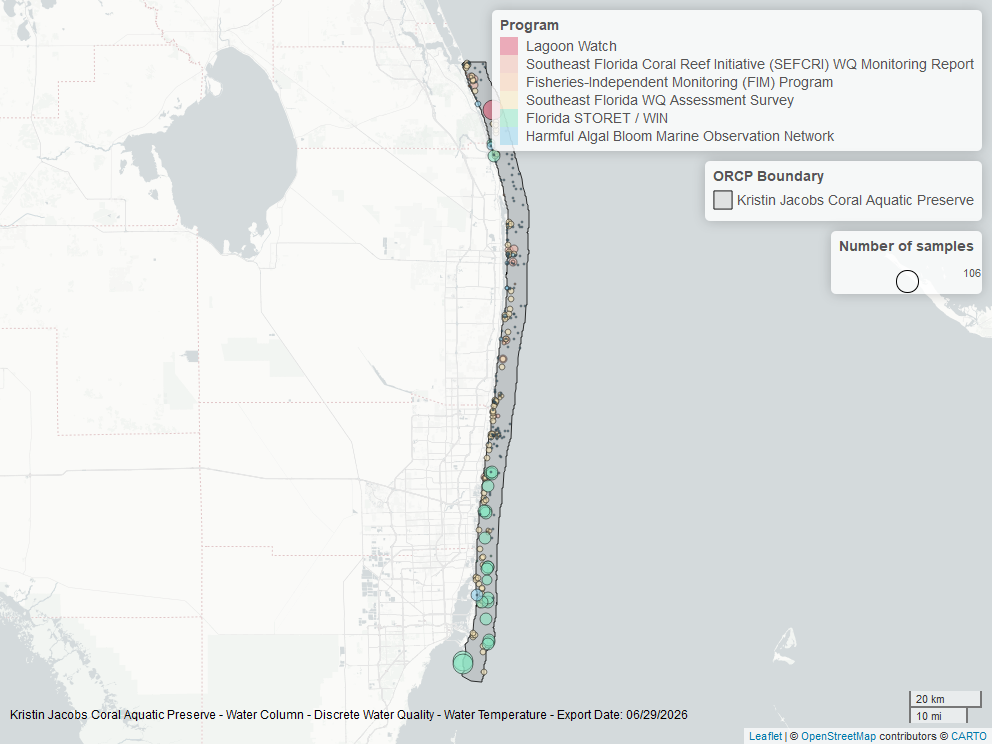

Map showing location of discrete water quality sampling locations within the boundaries of *Kristin Jacobs Coral Aquatic Preserve*. The bubble size on the maps above reflect the amount of data available at each sampling site.

### pH - Discrete

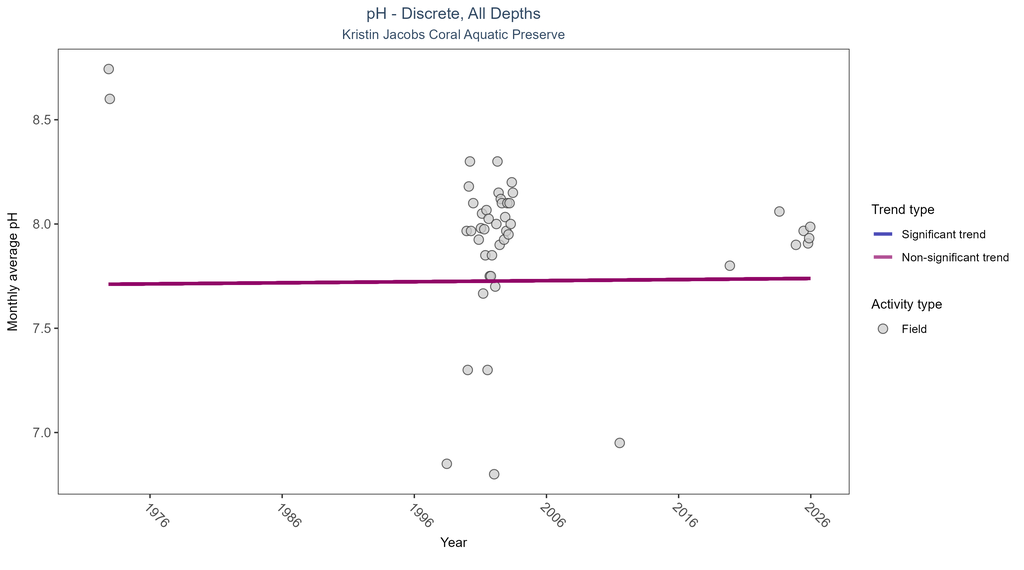

Scatter plot of monthly average pH over time. If the time series included ten or more years of discrete observations, a significant (blue) or non-significant (magenta) trend line is also shown. Only pH values measured in the field (circles) are included in the plot.

Table:

pH showed no detectable trend between 1972 and 2025.

| Activity Type | Statistical Trend | Sample Count | Years with Data | Period of Record | Median Result Value | Tau | Sen Intercept | Sen Slope | P |
| --- | --- | --- | --- | --- | --- | --- | --- | --- | --- |
| Field | No detectable trend | 988 | 12 | 1972 - 2025 | 7.96 | 0.09333 | 7.71072 | 0.00052 | 0.8606 |

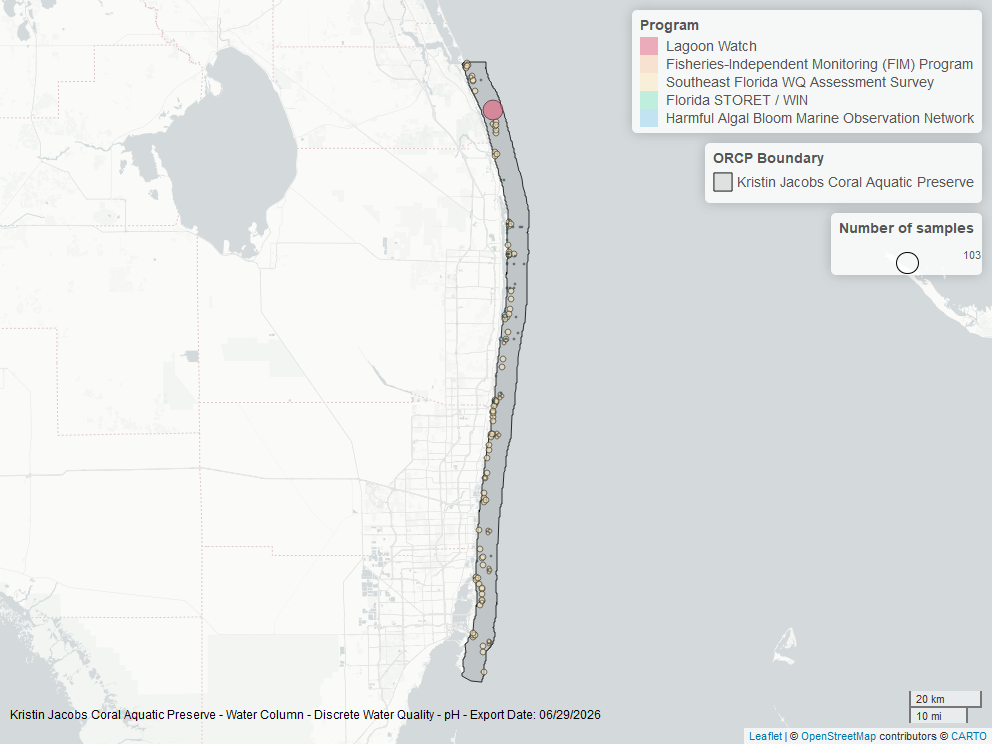

Map showing location of discrete water quality sampling locations within the boundaries of *Kristin Jacobs Coral Aquatic Preserve*. The bubble size on the maps above reflect the amount of data available at each sampling site.

## Water Clarity

### Turbidity - Discrete

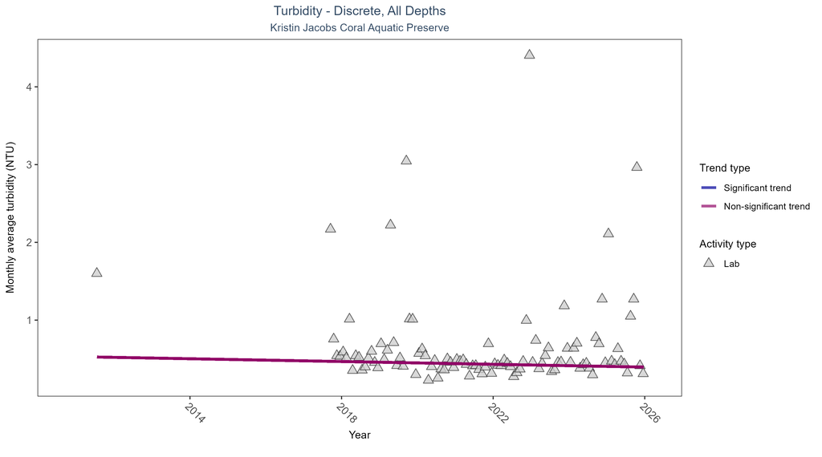

Scatter plot of monthly average turbidity over time. If the time series included ten or more years of discrete observations, a significant (blue) or non-significant (magenta) trend line is also shown. Only turbidity values measured in the laboratory (triangles) are included in the plot.

Table:

Turbidity showed no detectable trend between 2011 and 2025.

| Activity Type | Statistical Trend | Sample Count | Years with Data | Period of Record | Median Result Value | Tau | Sen Intercept | Sen Slope | P |
| --- | --- | --- | --- | --- | --- | --- | --- | --- | --- |
| Lab | No detectable trend | 19251 | 10 | 2011 - 2025 | 0.3 | -0.09477 | 0.53006 | -0.00894 | 0.2759 |

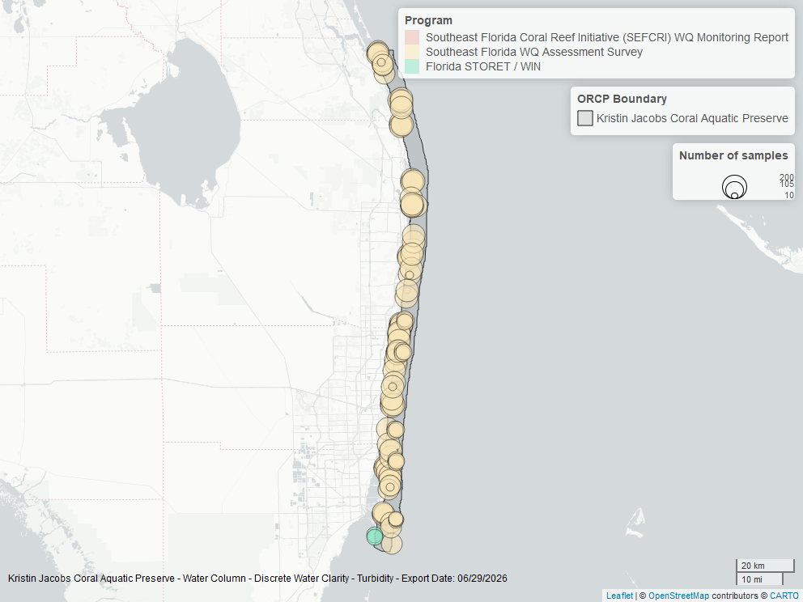

Map showing location of discrete water quality sampling locations within the boundaries of *Kristin Jacobs Coral Aquatic Preserve*. The bubble size on the maps above reflect the amount of data available at each sampling site.

### Total Suspended Solids - Discrete

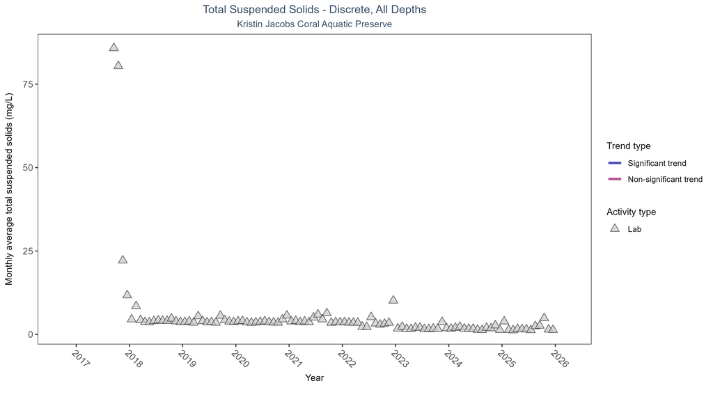

Scatter plot of monthly average total suspended solids (TSS) over time. If the time series included ten or more years of discrete observations, a significant (blue) or non-significant (magenta) trend line is also shown. Only TSS values obtained from laboratory analyses (triangles) are included in the plot.

Table:

There was insufficient data to fit a model for total suspended solids.

| Activity Type | Statistical Trend | Sample Count | Years with Data | Period of Record | Median Result Value | Tau | Sen Intercept | Sen Slope | P |
| --- | --- | --- | --- | --- | --- | --- | --- | --- | --- |
| Lab | Insufficient data | 18695 | 9 | 2017 - 2025 | 3.47 | - | - | - | - |

[figure not shown]

Map showing location of discrete water quality sampling locations within the boundaries of *Kristin Jacobs Coral Aquatic Preserve*. The bubble size on the maps above reflect the amount of data available at each sampling site.

### Chlorophyll a, Uncorrected for Pheophytin - Discrete

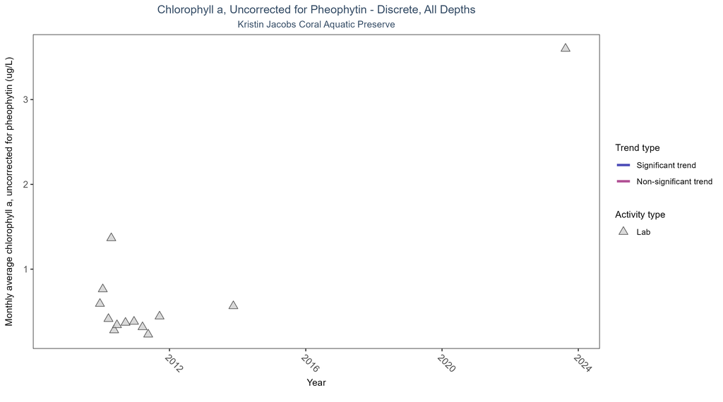

Scatter plot of monthly average levels of chlorophyll a, uncorrected for pheophytin, over time. If the time series included ten or more years of discrete observations, a significant (blue) or non-significant (magenta) trend line is also shown. Only laboratory-analyzed chlorophyll a (triangles) is included in the plot.

Table:

There was insufficient data to fit a model for chlorophyll a, uncorrected for pheophytin.

| Activity Type | Statistical Trend | Sample Count | Years with Data | Period of Record | Median Result Value | Tau | Sen Intercept | Sen Slope | P |
| --- | --- | --- | --- | --- | --- | --- | --- | --- | --- |
| Lab | Insufficient data | 328 | 5 | 2009 - 2023 | 0.3863 | - | - | - | - |

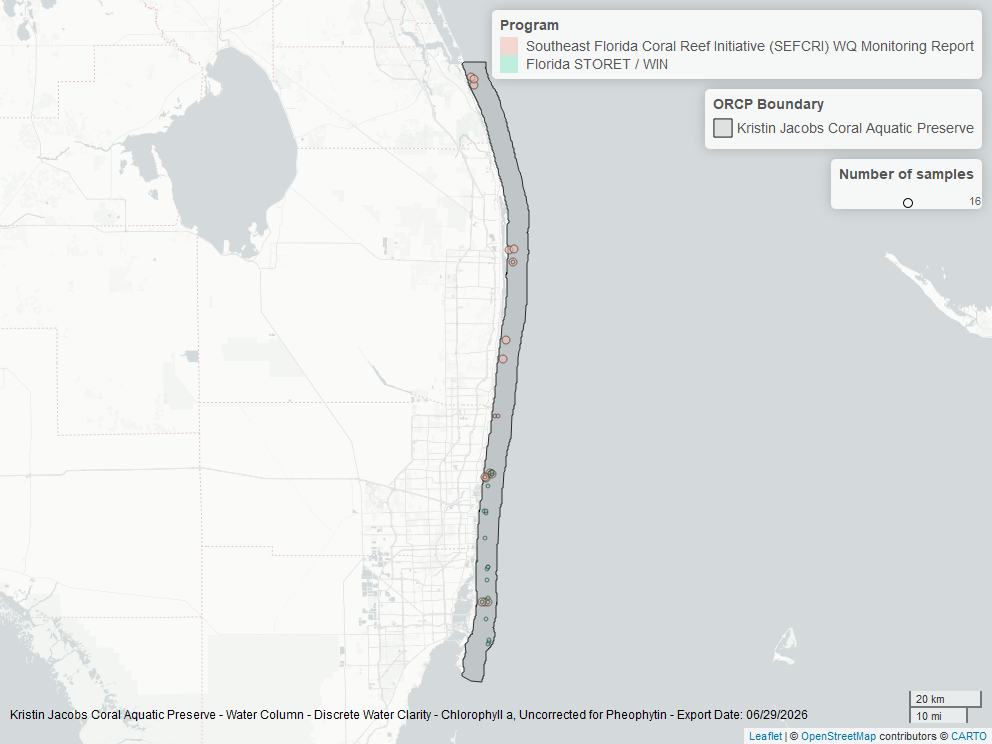

Map showing location of discrete water quality sampling locations within the boundaries of *Kristin Jacobs Coral Aquatic Preserve*. The bubble size on the maps above reflect the amount of data available at each sampling site.

### Chlorophyll a, Corrected for Pheophytin - Discrete

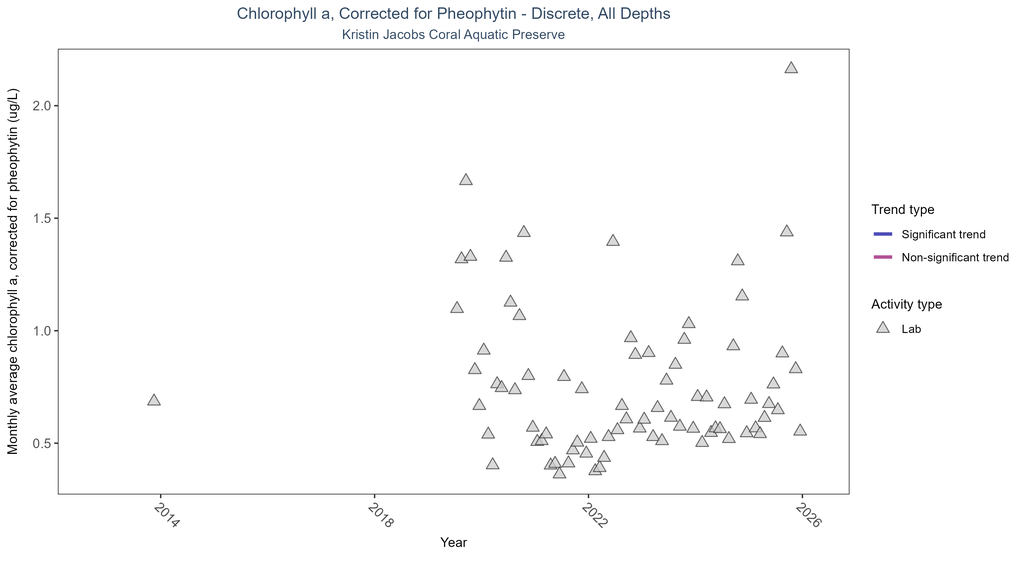

Scatter plot of monthly average levels of chlorophyll a, corrected for pheophytin, over time. If the time series included ten or more years of discrete observations, a significant (blue) or non-significant (magenta) trend line is also shown. Only laboratory-analyzed chlorophyll a (triangles) is included in the plot.

Table:

There was insufficient data to fit a model for chlorophyll a, corrected for pheophytin.

| Activity Type | Statistical Trend | Sample Count | Years with Data | Period of Record | Median Result Value | Tau | Sen Intercept | Sen Slope | P |
| --- | --- | --- | --- | --- | --- | --- | --- | --- | --- |
| Lab | Insufficient data | 13399 | 8 | 2013 - 2025 | 0.48 | - | - | - | - |

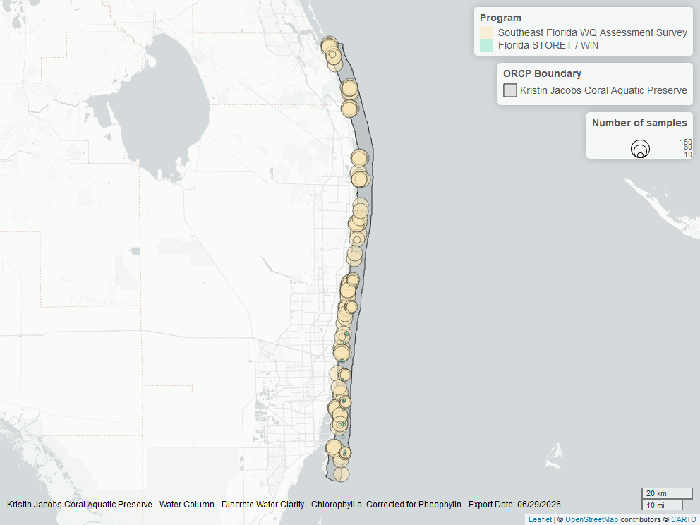

Map showing location of discrete water quality sampling locations within the boundaries of *Kristin Jacobs Coral Aquatic Preserve*. The bubble size on the maps above reflect the amount of data available at each sampling site.

### Secchi Depth - Discrete

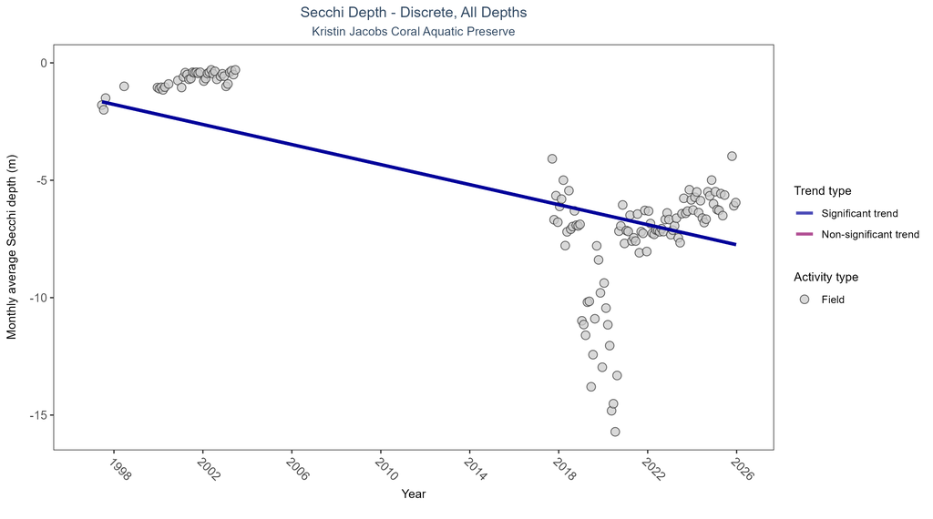

Scatter plot of monthly average Secchi depth over time. If the time series included ten or more years of discrete observations, a significant (blue) or non-significant (magenta) trend line is also shown. Secchi depth is only measured in the field (circles).

Table:

Monthly average Secchi depth became deeper by 0.21 m per year, indicating an increase in water clarity.

| Activity Type | Statistical Trend | Sample Count | Years with Data | Period of Record | Median Result Value | Tau | Sen Intercept | Sen Slope | P |
| --- | --- | --- | --- | --- | --- | --- | --- | --- | --- |
| Field | Decreasing trend | 9479 | 16 | 1997 - 2025 | -6 | -0.19671 | -1.55837 | -0.21338 | 0.0029 |

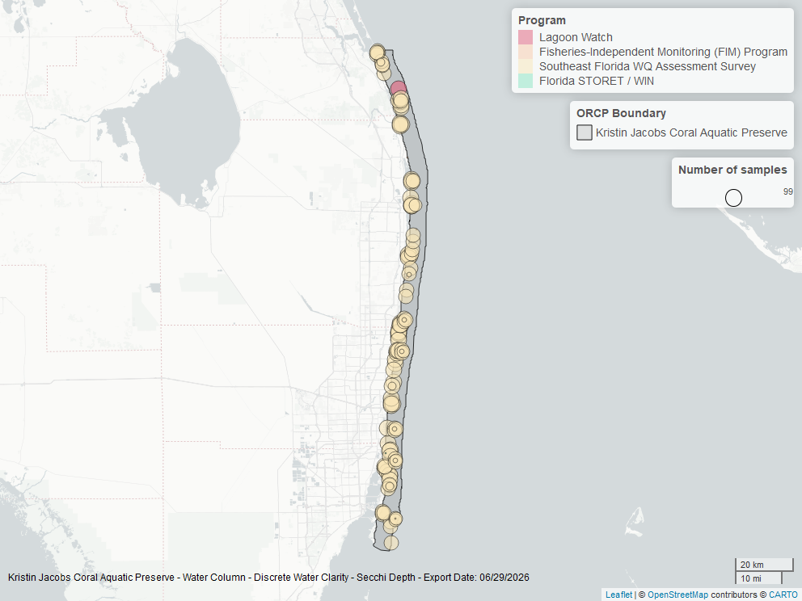

Map showing location of discrete water quality sampling locations within the boundaries of *Kristin Jacobs Coral Aquatic Preserve*. The bubble size on the maps above reflect the amount of data available at each sampling site.

### Colored Dissolved Organic Matter - Discrete

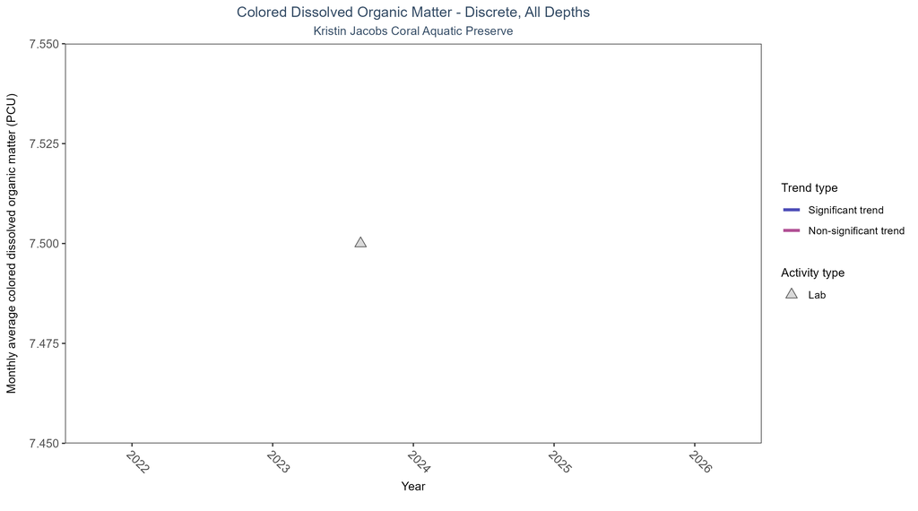

Scatter plot of monthly average colored dissolved organic matter (CDOM) over time. If the time series included ten or more years of discrete observations, a significant (blue) or non-significant (magenta) trend line is also shown. Only laboratory-analyzed CDOM (triangles) is included in the plot.

Table:

There was insufficient data to fit a model for colored dissolved organic matter.

| Activity Type | Statistical Trend | Sample Count | Years with Data | Period of Record | Median Result Value | Tau | Sen Intercept | Sen Slope | P |
| --- | --- | --- | --- | --- | --- | --- | --- | --- | --- |
| Lab | Insufficient data | 1 | 1 | 2023 - 2023 | 7.5 | - | - | - | - |

[figure not shown]

Map showing location of discrete water quality sampling locations within the boundaries of *Kristin Jacobs Coral Aquatic Preserve*. The bubble size on the maps above reflect the amount of data available at each sampling site.